# AMS 580 Final Exam Part 3

Denis O’Byrne

5/13/2021

# Part III. Unsupervised Learning with the GreatUnknown Data

# Now we are back to the same GreatUnknown.csv data in Part I containing 12 predictors and one binary response variable y (= 0 or 1), which is the true class label.

# For this dataset, sensitivity is defined as a case labeled 1 being classified to label 1, while specificity is defined as a case labeled 0 being classified to label 0.

# 1. Our goal is to predict the class label based on the 12 predictors given. Subsequently we wish to compare our data-driven clustering to that of the true class label (given by y). For each of the following three clustering methods (K-mean; Hierarchical: Ward, and, Average Linkage), we need you to:

# a) Perform the clustering analysis;

# b) Draw scree-plot to see whether two clusters is reasonable or not;

# c) Show the 2D representation of the Cluster solution;

# d) Build a confusion matrix to evaluate the clustering performance;

# For Hierarchical clustering, please also draw the dendrogram showing the two clusters obtained;

# e) Build a confusion matrix to compare the clustering results of the K-means and the Ward’s method;

# f) Finally, make a comparison of all three clustering methods, and rank their performance for the given problem.

# Setup

```r
library(tidyverse)
library(caret)
library(neuralnet)
library(randomForest)
library(rpart)
library(rattle)
library(MASS)
library(tidyverse)
library(glmnet)
```

```r
library(leaps)
library(ggplot2)


gun<-read.csv("C:/Users/denis/Downloads/GreatUnknown.csv", header = TRUE)

head(gun)
```

```
##     w1   w2   w3   w4   w5 w6   w7   w8   w9   w10 w11   w12 y
## 1 0.32 0.00 0.00 0.32 0.00  0 0.00 0.00 0.00 0.000   0 0.000 1
## 2 0.14 0.21 0.94 0.14 0.00  0 0.00 0.00 0.00 0.132   0 0.180 1
## 3 1.23 0.19 0.25 0.06 0.32  0 0.06 0.06 0.01 0.143   0 0.184 1
## 4 0.63 0.31 0.63 0.31 0.00  0 0.00 0.00 0.00 0.137   0 0.000 1
## 5 0.63 0.31 0.63 0.31 0.00  0 0.00 0.00 0.00 0.135   0 0.000 1
## 6 1.85 0.00 0.00 0.00 0.00  0 0.00 0.00 0.00 0.223   0 0.000 1
```

```r
dim(gun)
```

```
## [1] 4601   13
```

```r
gun<-na.omit(gun)

dim(gun)
```

```
## [1] 4601   13
```

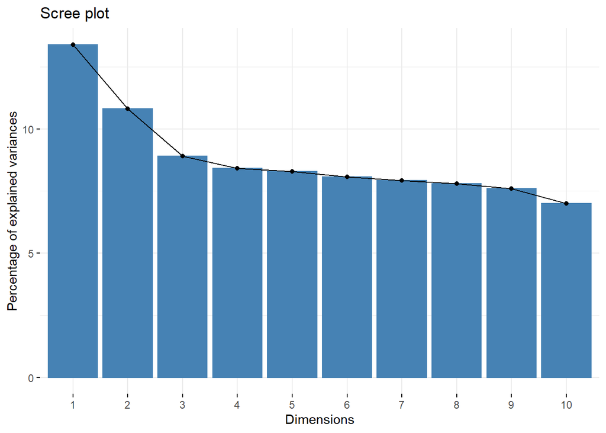

```r
y<-gun$y
x<-gun[-13]

x<-scale(x)

pc = princomp(x, cor = T)
# Scree-plot
library(factoextra)
fviz_eig(pc)
```

# K means

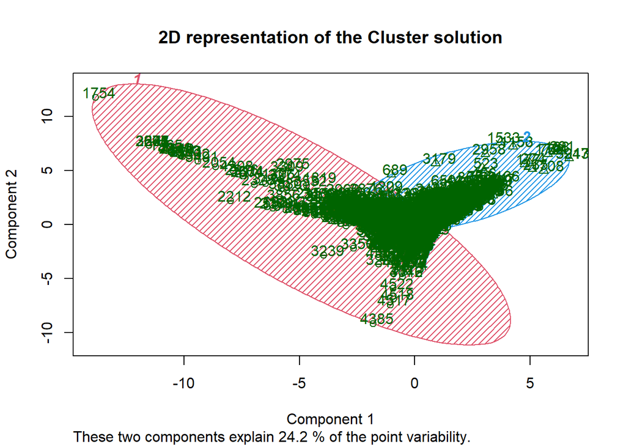

```r
k.means.fit <- kmeans(x, 2)
library(cluster)
clusplot(x, k.means.fit$cluster, main='2D representation of the Cluster solution',color=TRUE, shade=TRUE,labels=2, lines=0)
```

```r
table(k.means.fit$cluster, y)
```

```
##    y
##        0    1
##   1 2643  900
##   2  145  913
```

# Kmeans Accuracy

```r
(2643+913)/(900+145+2643+913)
```

```
## [1] 0.7728755
```

# H.Ward

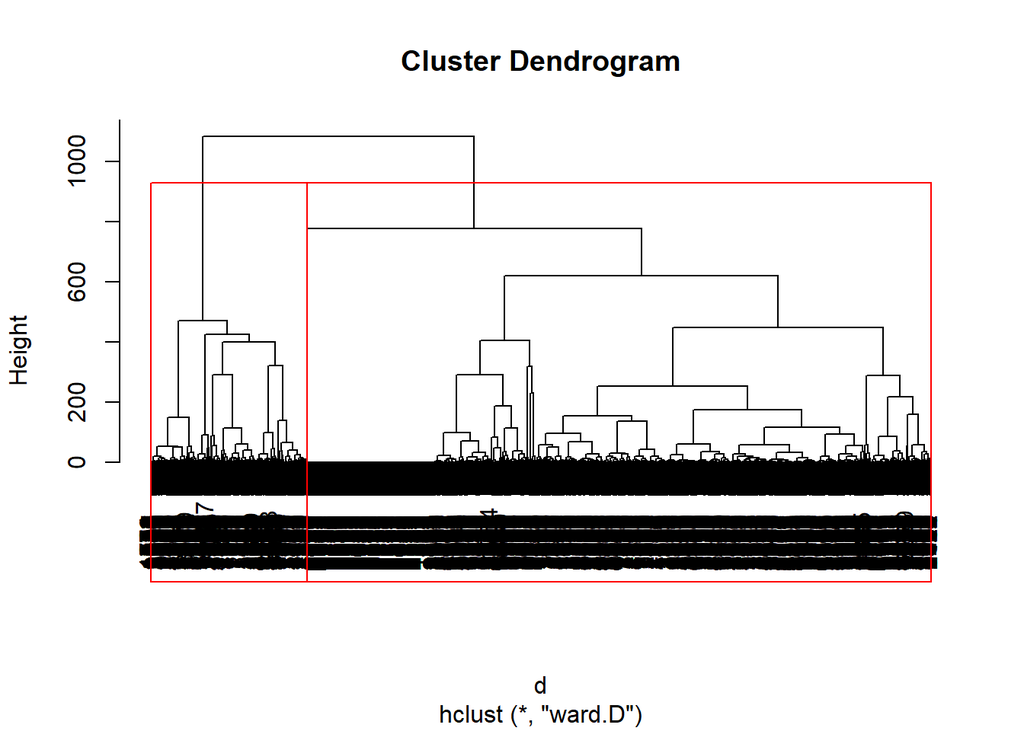

```r
d <- dist(x, method = "euclidean")
H.fit <- hclust(d, method="ward.D")
plot(H.fit)
rect.hclust(H.fit, k=2, border="red")
```

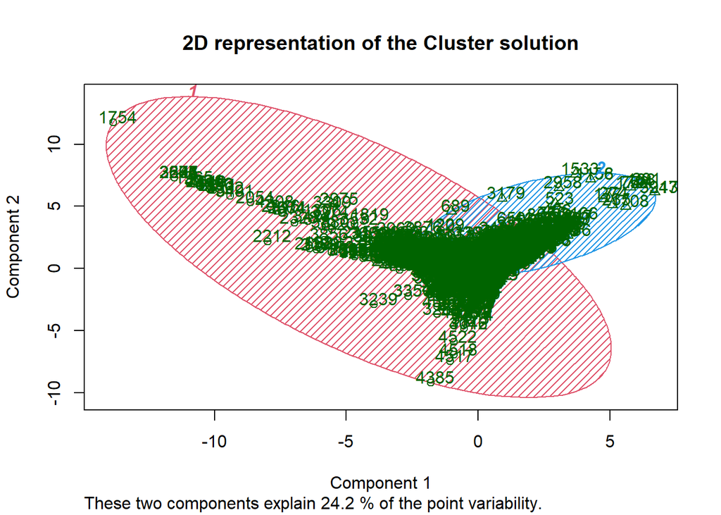

```r
groups <- cutree(H.fit, k=2)
clusplot(x, groups, main='2D representation of the Cluster solution',color=TRUE, shade=TRUE,labels=2, lines=0)
```

```r
clusters = factor(groups, levels = 1:2)
table(y, clusters)
```

```
##    clusters
## y      1    2
##   0 2621  167
##   1 1059  754
```

# Hward Accuracy

```r
(2621+754)/(2621+754+167+1059)
```

```
## [1] 0.7335362
```

# H.Single

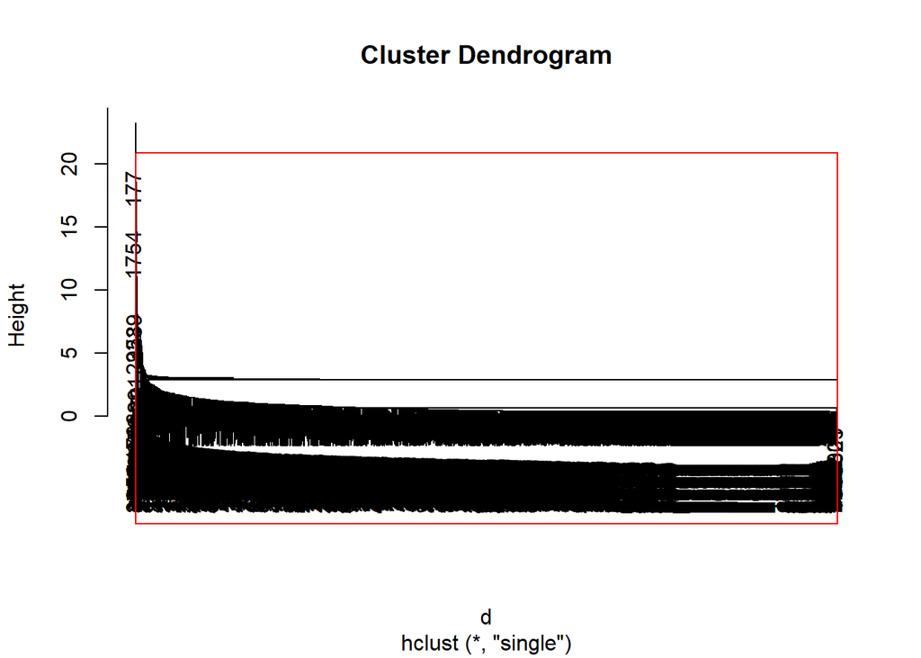

```r
H.fit <- hclust(d, method="single")
plot(H.fit)
rect.hclust(H.fit, k=2, border="red")
```

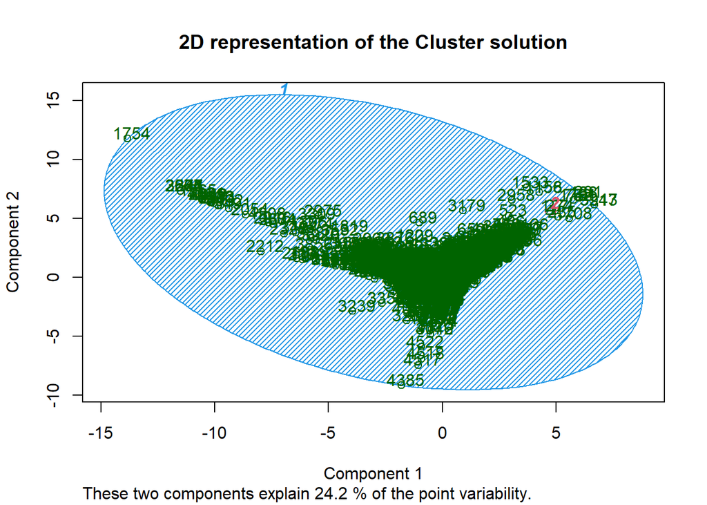

```r
groups <- cutree(H.fit, k=2)
clusplot(x, groups, main='2D representation of the Cluster solution',color=TRUE, shade=TRUE,labels=2, lines=0)
```

```r
clusters = factor(groups, levels = 1:2)
table(y, clusters)
```

```
##    clusters
## y      1    2
##   0 2788    0
##   1 1812    1
```

# H.Single Accuracy

```r
(2788+1)/(1812+2788+1+0)
```

```
## [1] 0.6061726
```

# H.Complete

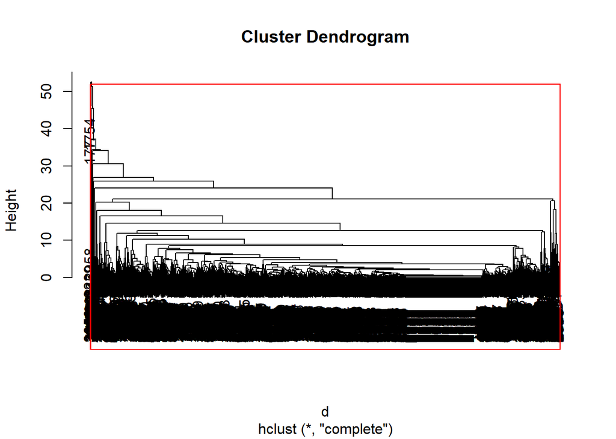

```r
H.fit <- hclust(d, method="complete")
plot(H.fit)
rect.hclust(H.fit, k=2, border="red")
```

[figure not shown]

```r
groups <- cutree(H.fit, k=2)
clusplot(x, groups, main='2D representation of the Cluster solution',color=TRUE, shade=TRUE,labels=2, lines=0)
```

```r
clusters = factor(groups, levels = 1:2)
table(y, clusters)
```

```
##    clusters
## y      1    2
##   0 2785    3
##   1 1813    0
```

# H.Complete Accuracy

```r
2785/(2785+1813+3+0)
```

```
## [1] 0.6053032
```

# H.Average

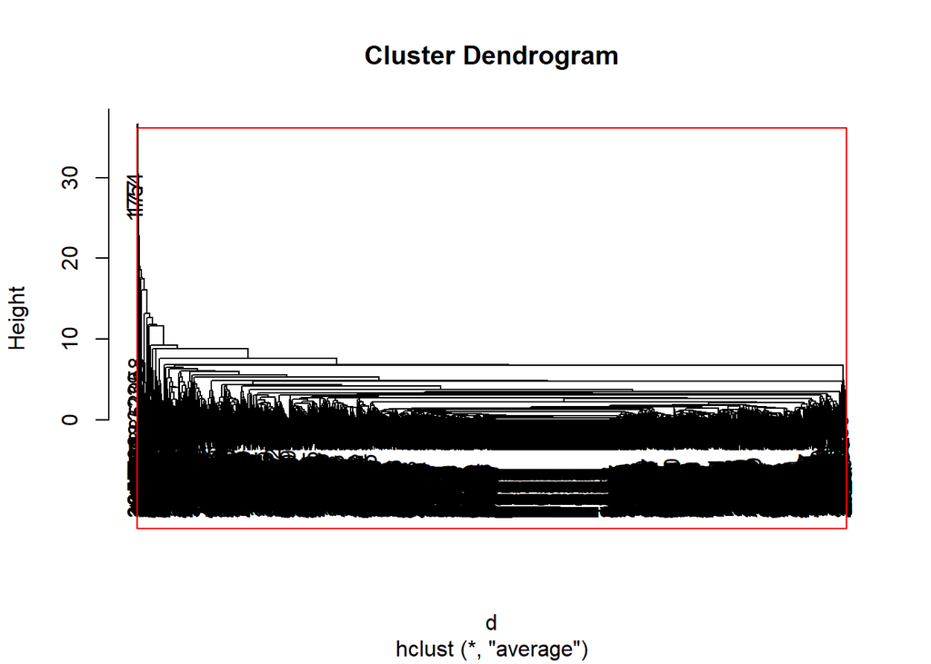

```r
H.fit <- hclust(d, method="average")
plot(H.fit)
rect.hclust(H.fit, k=2, border="red")
```

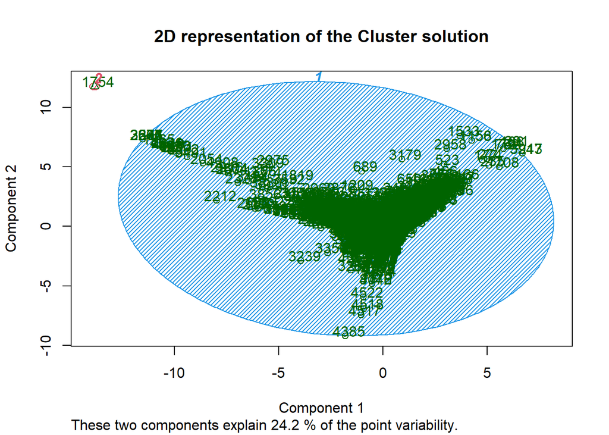

```r
groups <- cutree(H.fit, k=2)
clusplot(x, groups, main='2D representation of the Cluster solution',color=TRUE, shade=TRUE,labels=2, lines=0)
```

```r
clusters = factor(groups, levels = 1:2)
table(y, clusters)
```

```
##    clusters
## y      1    2
##   0 2788    0
##   1 1812    1
```

# H.Average Accuracy

```r
(2788+1)/(2788+1812+1)
```

```
## [1] 0.6061726
```

# H.Centroid

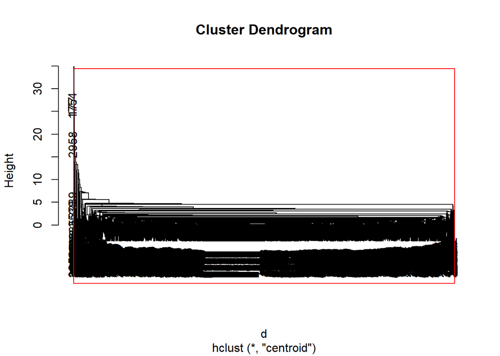

```r
H.fit <- hclust(d, method="centroid")
plot(H.fit)
rect.hclust(H.fit, k=2, border="red")
```

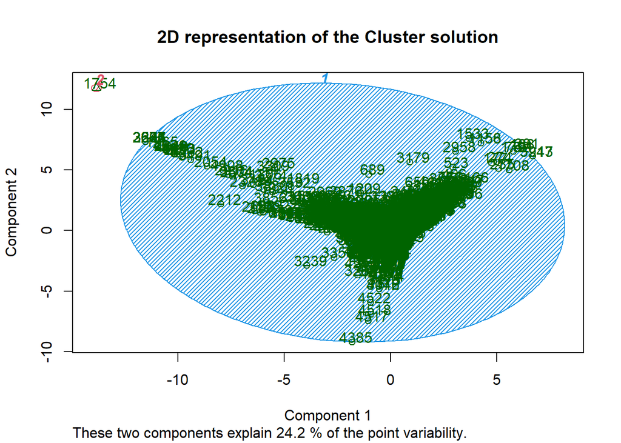

```r
groups <- cutree(H.fit, k=2)
clusplot(x, groups, main='2D representation of the Cluster solution',color=TRUE, shade=TRUE,labels=2, lines=0)
```

```r
clusters = factor(groups, levels = 1:2)
table(y, clusters)
```

```
##    clusters
## y      1    2
##   0 2788    0
##   1 1812    1
```

# H.Centroid Accuracy

```r
(2788+1)/(2788+1812+1)
```

```
## [1] 0.6061726
```

# K-means clustering performed the best with a total accuracy of 0.7728755

# For this problem:

# K-means > HWard > HSingle = HAverage = HCentroid > HComplete

# 2. Please write up the entire R code necessary to answer the following questions use the same data set:

# a) Please compute the Principal Components (PC’s) using the 12 predictors and print out a summary of the analysis – and in particular, please point out what percentage of the variations each PC would explain.

# b) Please make a biplot, which includes both the position of each sample in terms of PC1 and PC2 and will also show you how the initial variables map onto this.

# c) Now you will utilize the true class label (y) information binning the data into two groups: y = 0, and y = 1. You will visualize the biplot by setting the ellipse argument to be TRUE, which will draw an ellipse around each group.

# d) Last but not the least, we shall print out the PC1 as linear combinations of the original variables. How would you interpret PC1 in terms of the original variables?

```r
library(devtools)
```

```r
library(ggbiplot)
y<-gun$y
x<-gun[-13]

x<-scale(x)
```

# (a)

```r
gun.pca = prcomp(x, center = TRUE,scale. = TRUE)
summary(gun.pca)
```

```
## Importance of components:
##                           PC1    PC2    PC3     PC4     PC5     PC6     PC7
## Standard deviation     1.2677 1.1389 1.0340 1.00462 0.99711 0.98418 0.97543
## Proportion of Variance 0.1339 0.1081 0.0891 0.08411 0.08285 0.08072 0.07929
## Cumulative Proportion  0.1339 0.2420 0.3311 0.41522 0.49807 0.57879 0.65807
##                            PC8     PC9    PC10    PC11    PC12
## Standard deviation     0.96718 0.95444 0.91643 0.89253 0.78756
## Proportion of Variance 0.07795 0.07591 0.06999 0.06638 0.05169
## Cumulative Proportion  0.73603 0.81194 0.88193 0.94831 1.00000
```

The proportions of variation by principal component are # Pc1 = 13.39% # PC2 = 10.81% # PC3 = 8.91% # PC4 = 8.411% # PC5 = 8.285% # PC6 = 8.072% # PC7 = 7.929% # PC8 = 7.795% # PC9 = 7.591% # PC10 = 6.999% # PC11 = 6.638% # PC12 = 5.169%

# (b)

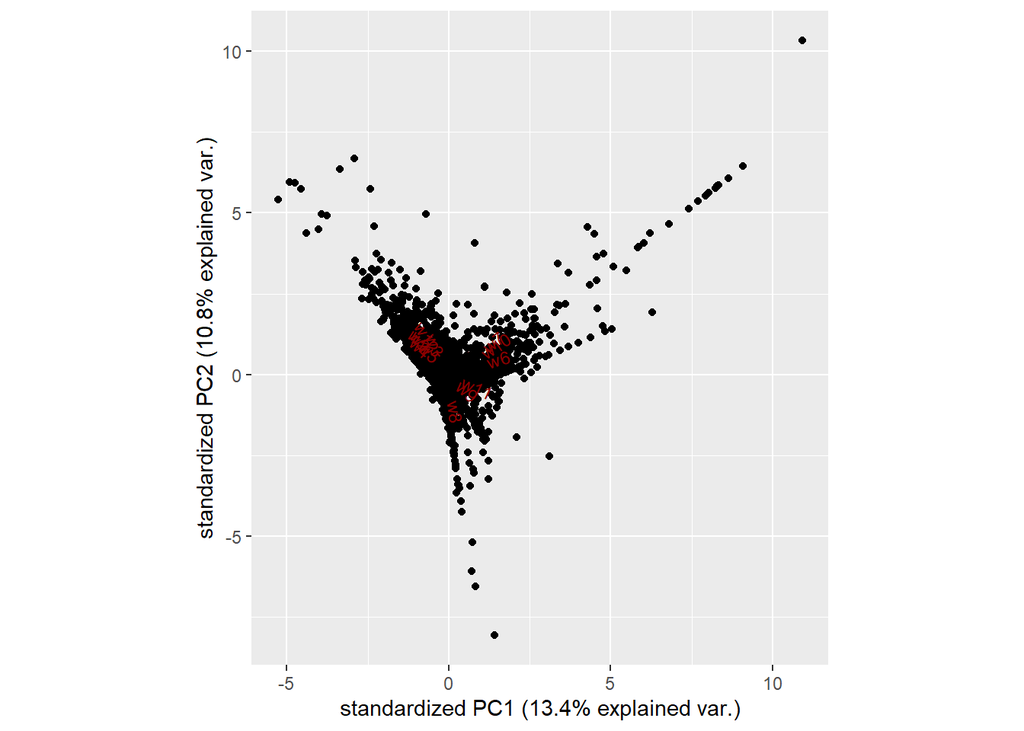

```r
ggbiplot(gun.pca)
```

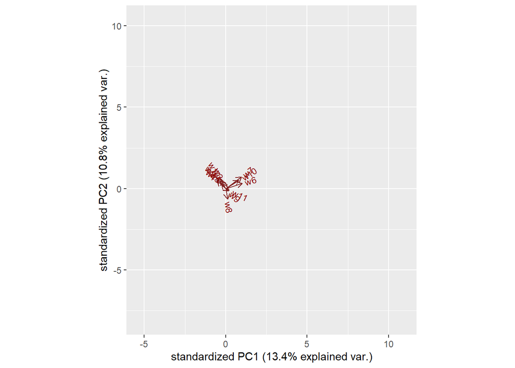

```r
# just vectors
ggbiplot(gun.pca, alpha = 0)
```

# (c)

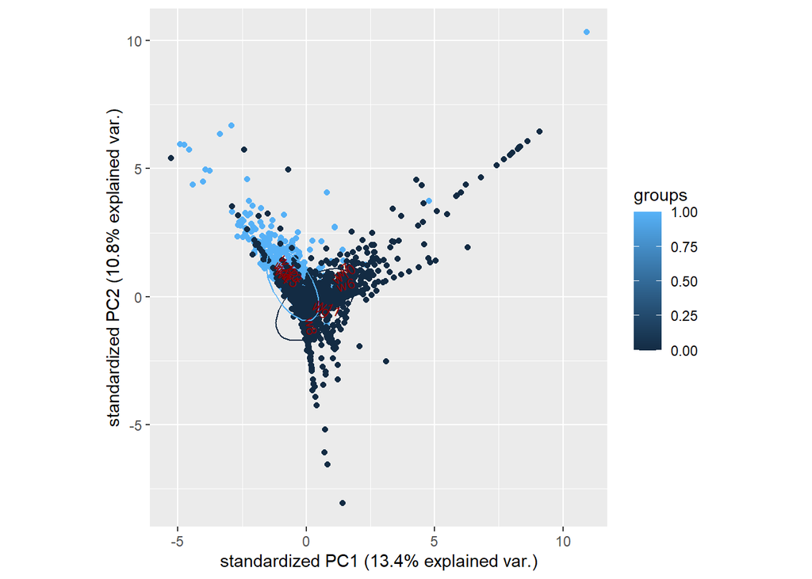

```r
ggbiplot(gun.pca, ellipse=TRUE, groups=y)
```

# (d)

```r
gun.pca$rotation[,1] #PC1
```

```
##          w1          w2          w3          w4          w5          w6
## -0.26312837 -0.30497476 -0.10446981 -0.27139508 -0.13025875  0.52197111
##          w7          w8          w9         w10         w11         w12
##  0.49664611  0.05810733  0.08953016  0.40916977  0.10868236 -0.16273359
```

# The dependence of PC1 on the variables nonzero for all variables so it is not easily explained making it hard to interpret the model produced by the PCA.